# Data Cleaning and Exploratory Analysis with R

Mary Mbugua

01/07/2021

# Specifying the Question

**Defining the Question** Identify customers who are most likely to click the AD(online cryptography course) advertised on a Kenyan enterprenuer blog.

**Metric of Success** We will consider our analysis as successful if it will accurately predict whether a customer will click an AD or not.

**Context** A Kenyan entrepreneur has created an online cryptography course and would want to advertise it on her blog. She currently targets audiences originating from various countries. In the past, she ran ads to advertise a related course on the same blog and collected data in the process. She would now like to employ your services as a Data Science Consultant to help her identify which individuals are most likely to click on her ads.

**Experimental Design Taken:**

-Importing the dataset

- Performing Data Cleaning
- Checking outliers
- Performing Univariate analysis
- Performing Bivariate analysis
- Performing multivariate analysis
- Conclusions and Recommedations.

**Appropriateness of the available data**

The dataset contains the following fields

-Daily time spent on site

-Age

-Area Income

-Daily Internet usage

- AD Topic line
- City
- Male
- Country

-Timestamp

-Clicked on Ad

# Importing our dataset

```r
advertising=read.csv("http://bit.ly/IPAdvertisingData")
head(advertising)
```

```
##   Daily.Time.Spent.on.Site Age Area.Income Daily.Internet.Usage
## 1                    68.95  35    61833.90               256.09
## 2                    80.23  31    68441.85               193.77
## 3                    69.47  26    59785.94               236.50
## 4                    74.15  29    54806.18               245.89
## 5                    68.37  35    73889.99               225.58
## 6                    59.99  23    59761.56               226.74
##                           Ad.Topic.Line           City Male    Country
## 1    Cloned 5thgeneration orchestration    Wrightburgh    0    Tunisia
## 2    Monitored national standardization      West Jodi    1      Nauru
## 3      Organic bottom-line service-desk       Davidton    0 San Marino
## 4 Triple-buffered reciprocal time-frame West Terrifurt    1      Italy
## 5         Robust logistical utilization   South Manuel    0    Iceland
## 6       Sharable client-driven software      Jamieberg    1     Norway
##             Timestamp Clicked.on.Ad
## 1 2016-03-27 00:53:11             0
## 2 2016-04-04 01:39:02             0
## 3 2016-03-13 20:35:42             0
## 4 2016-01-10 02:31:19             0
## 5 2016-06-03 03:36:18             0
## 6 2016-05-19 14:30:17             0
```

**Checking the tail of our dataset**

```r
tail(advertising)
```

```
##      Daily.Time.Spent.on.Site Age Area.Income Daily.Internet.Usage
## 995                     43.70  28    63126.96               173.01
## 996                     72.97  30    71384.57               208.58
## 997                     51.30  45    67782.17               134.42
## 998                     51.63  51    42415.72               120.37
## 999                     55.55  19    41920.79               187.95
## 1000                    45.01  26    29875.80               178.35
##                             Ad.Topic.Line          City Male
## 995         Front-line bifurcated ability  Nicholasland    0
## 996         Fundamental modular algorithm     Duffystad    1
## 997       Grass-roots cohesive monitoring   New Darlene    1
## 998          Expanded intangible solution South Jessica    1
## 999  Proactive bandwidth-monitored policy   West Steven    0
## 1000      Virtual 5thgeneration emulation   Ronniemouth    0
##                     Country           Timestamp Clicked.on.Ad
## 995                 Mayotte 2016-04-04 03:57:48             1
## 996                 Lebanon 2016-02-11 21:49:00             1
## 997  Bosnia and Herzegovina 2016-04-22 02:07:01             1
## 998                Mongolia 2016-02-01 17:24:57             1
## 999               Guatemala 2016-03-24 02:35:54             0
## 1000                 Brazil 2016-06-03 21:43:21             1
```

**Checking more information about our dataset**

```r
str(advertising)
```

```
## 'data.frame':    1000 obs. of  10 variables:
##  $ Daily.Time.Spent.on.Site: num  69 80.2 69.5 74.2 68.4 ...
##  $ Age                     : int  35 31 26 29 35 23 33 48 30 20 ...
##  $ Area.Income             : num  61834 68442 59786 54806 73890 ...
##  $ Daily.Internet.Usage    : num  256 194 236 246 226 ...
##  $ Ad.Topic.Line           : chr  "Cloned 5thgeneration orchestration" "Monitored national standardization" "Organic bottom-line service-desk" "Triple-buffered reciprocal time-frame" ...
##  $ City                    : chr  "Wrightburgh" "West Jodi" "Davidton" "West Terrifurt" ...
##  $ Male                    : int  0 1 0 1 0 1 0 1 1 1 ...
##  $ Country                 : chr  "Tunisia" "Nauru" "San Marino" "Italy" ...
##  $ Timestamp               : chr  "2016-03-27 00:53:11" "2016-04-04 01:39:02" "2016-03-13 20:35:42" "2016-01-10 02:31:19" ...
##  $ Clicked.on.Ad           : int  0 0 0 0 0 0 0 1 0 0 ...
```

**Checking the dimension of the dataset**

```r
 dim(advertising)
```

```
## [1] 1000   10
```

**Checking the class of the dataset**

```r
 class(advertising)
```

```
## [1] "data.frame"
```

# Data Cleaning

## Missing Data

**Identifying the missing data in our dataset**

```r
is.na(head(advertising))
```

```
##   Daily.Time.Spent.on.Site   Age Area.Income Daily.Internet.Usage Ad.Topic.Line
## 1                    FALSE FALSE       FALSE                FALSE         FALSE
## 2                    FALSE FALSE       FALSE                FALSE         FALSE
## 3                    FALSE FALSE       FALSE                FALSE         FALSE
## 4                    FALSE FALSE       FALSE                FALSE         FALSE
## 5                    FALSE FALSE       FALSE                FALSE         FALSE
## 6                    FALSE FALSE       FALSE                FALSE         FALSE
##    City  Male Country Timestamp Clicked.on.Ad
## 1 FALSE FALSE   FALSE     FALSE         FALSE
## 2 FALSE FALSE   FALSE     FALSE         FALSE
## 3 FALSE FALSE   FALSE     FALSE         FALSE
## 4 FALSE FALSE   FALSE     FALSE         FALSE
## 5 FALSE FALSE   FALSE     FALSE         FALSE
## 6 FALSE FALSE   FALSE     FALSE         FALSE
```

**Let’s find out the total missing values in each column**

```r
colSums(is.na(advertising))
```

```
## Daily.Time.Spent.on.Site                      Age              Area.Income
##                        0                        0                        0
##     Daily.Internet.Usage            Ad.Topic.Line                     City
##                        0                        0                        0
##                     Male                  Country                Timestamp
##                        0                        0                        0
##            Clicked.on.Ad
##                        0
```

-This indicates that there are no missing values in our dataset.

## Duplicates

**Identifying duplicated records in our dataset**

duplicated_rows <-advertising[duplicated(advertising),] duplicated_rows

**Removing duplicated rows** unique_items <- unique(advertising) unique_items

# Outliers

**Boxplot**

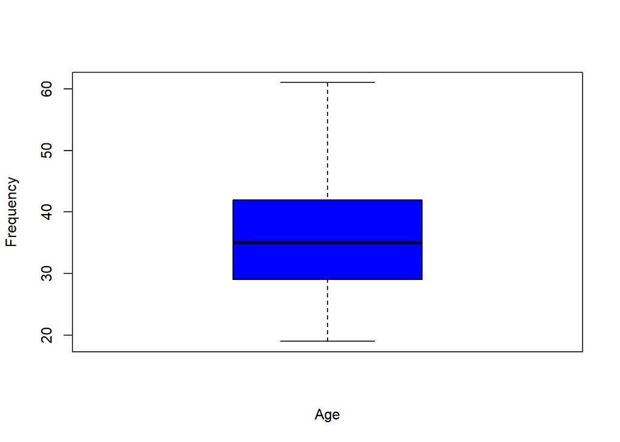

```r
boxplot(advertising$Age,col=c("blue"),xlab="Age",ylab="Frequency",legend=row.names("Age"))
```

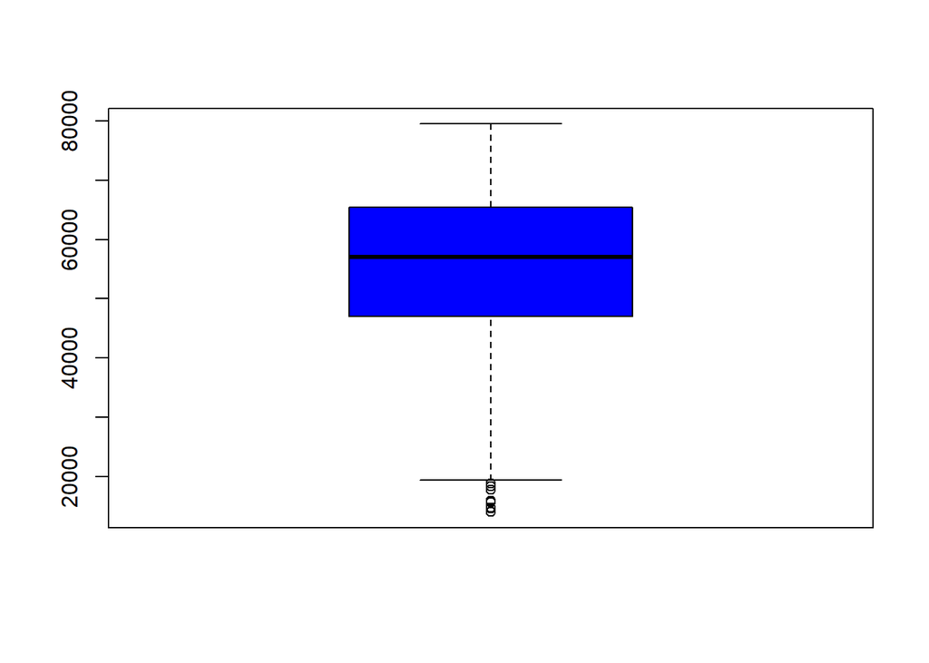

```r
boxplot(advertising$Area.Income,col=c("blue"))
```

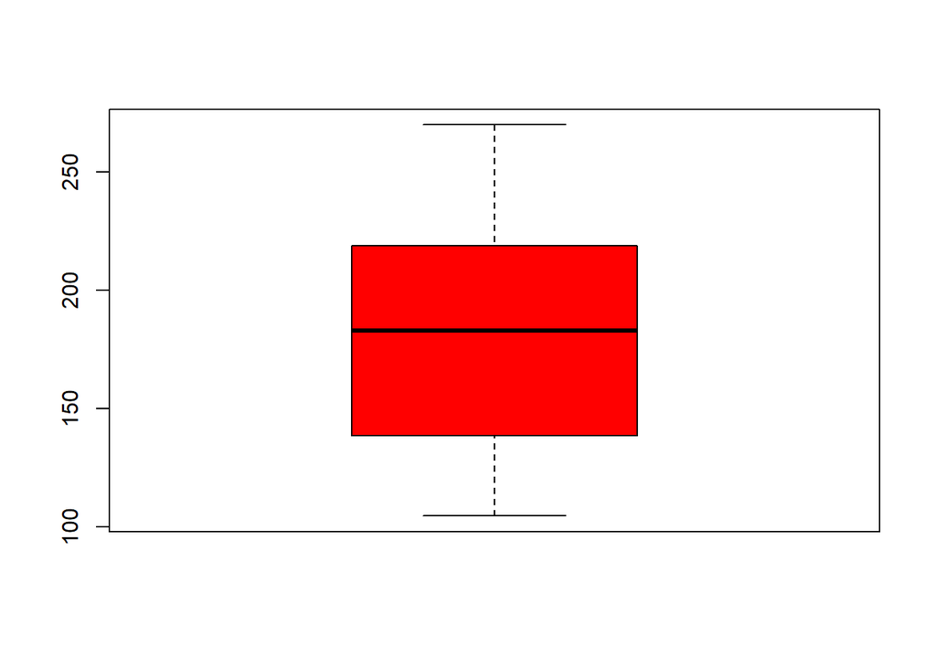

```r
boxplot(advertising$Daily.Internet.Usage,col=c("red"))
```

-We will not eliminate the outliers as they contain some possible scenarios in the society.They might also affect our analysis if we remove them.

# Univariate Analysis

**Mean**

Finding the mean of the following columns -Age

-Daily Time Spent on site

-Area income

_Daily internet usage

```r
Age_mean<-mean(advertising$Age)
Age_mean
```

```
## [1] 36.009
```

```r
Daily.Time.Spent.on.Site_mean<-mean(advertising$Daily.Time.Spent.on.Site)
Daily.Time.Spent.on.Site_mean
```

```
## [1] 65.0002
```

```r
Area.Income_mean<-mean(advertising$Area.Income)
Area.Income_mean
```

```
## [1] 55000
```

```r
Daily.Internet.Usage_mean<-mean(advertising$Daily.Internet.Usage)
Daily.Internet.Usage_mean
```

```
## [1] 180.0001
```

**Median**

```r
Age_median<-median(advertising$Age)
Age_median
```

```
## [1] 35
```

```r
Daily.Time.Spent.on.Site_median<-median(advertising$Daily.Time.Spent.on.Site)
Daily.Time.Spent.on.Site_median
```

```
## [1] 68.215
```

```r
Area.Income_median<-median(advertising$Area.Income)
Area.Income_median
```

```
## [1] 57012.3
```

```r
Daily.Internet.Usage_median<-median(advertising$Daily.Internet.Usage)
Daily.Internet.Usage_median
```

```
## [1] 183.13
```

# Mesures of Dispersion

**Maximum**

```r
Age_maximum<-max(advertising$Age)
Age_maximum
```

```
## [1] 61
```

```r
Area.Income_max<-max(advertising$Area.Income)
Area.Income_max
```

```
## [1] 79484.8
```

```r
Daily.Internet.Usage_max<-max(advertising$Daily.Internet.Usage)
Daily.Internet.Usage_max
```

```
## [1] 269.96
```

```r
Daily.Time.Spent.on.Site_max<-max(advertising$Daily.Time.Spent.on.Site)
Daily.Time.Spent.on.Site_max
```

```
## [1] 91.43
```

**Minimum**

```r
Age_min<-min(advertising$Age)
Age_min
```

```
## [1] 19
```

```r
Area.Income_min<-min(advertising$Area.Income)
Area.Income_min
```

```
## [1] 13996.5
```

```r
Daily.Internet.Usage_min<-min(advertising$Daily.Internet.Usage)
Daily.Internet.Usage_min
```

```
## [1] 104.78
```

```r
Daily.Time.Spent.on.Site_min<-min(advertising$Daily.Time.Spent.on.Site)
Daily.Time.Spent.on.Site_min
```

```
## [1] 32.6
```

**Quantiles**

```r
Age_quantile<-quantile(advertising$Age)
Age_quantile
```

```
##   0%  25%  50%  75% 100%
##   19   29   35   42   61
```

```r
Area.Income_quantile<-quantile(advertising$Area.Income)
Area.Income_quantile
```

```
##       0%      25%      50%      75%     100%
## 13996.50 47031.80 57012.30 65470.64 79484.80
```

```r
Daily.Internet.Usage_quantile<-quantile(advertising$Daily.Internet.Usage)
Daily.Internet.Usage_quantile
```

```
##       0%      25%      50%      75%     100%
## 104.7800 138.8300 183.1300 218.7925 269.9600
```

```r
Daily.Time.Spent.on.Site_quantile<-quantile(advertising$Daily.Time.Spent.On.Site)
Daily.Time.Spent.on.Site_quantile
```

```
##   0%  25%  50%  75% 100%
##   NA   NA   NA   NA   NA
```

**Variance**

```r
Age_var<-var(advertising$Age)
Age_var
```

```
## [1] 77.18611
```

```r
Area.Income_var<-var(advertising$Area.Income)
Area.Income_var
```

```
## [1] 179952406
```

```r
Daily.Internet.Usage_ver<-var(advertising$Daily.Internet.Usage)
Daily.Internet.Usage_ver
```

```
## [1] 1927.415
```

```r
Daily.Time.Spent.on.Site_var<-var(advertising$Daily.Time.Spent.on.Site)
Daily.Time.Spent.on.Site_var
```

```
## [1] 251.3371
```

**Standard Deviation**

```r
Age_sd<-sd(advertising$Age)
Age_sd
```

```
## [1] 8.785562
```

```r
Area.Income_sd<-sd(advertising$Area.Income)
Area.Income_sd
```

```
## [1] 13414.63
```

```r
Daily.Internet.Usage_sd<-sd(advertising$Daily.Internet.Usage)
Daily.Internet.Usage_sd
```

```
## [1] 43.90234
```

```r
Daily.Time.Spent.on.Site_sd<-sd(advertising$Daily.Time.Spent.on.Site)
Daily.Time.Spent.on.Site_sd
```

```
## [1] 15.85361
```

**BarPlots**

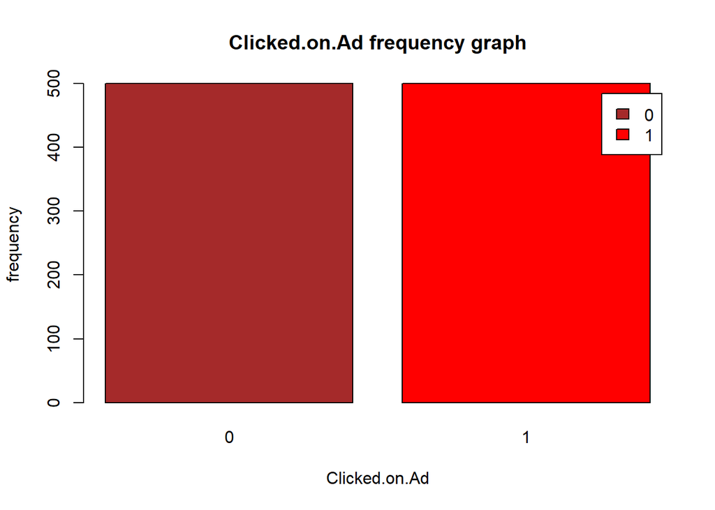

```r
count_clicked<- table(advertising$Clicked.on.Ad)
barplot(count_clicked,main="Clicked.on.Ad frequency graph", xlab="Clicked.on.Ad",ylab= "frequency",legend=row.names(count_clicked),col=c("brown","red"))
```

**Histograms**

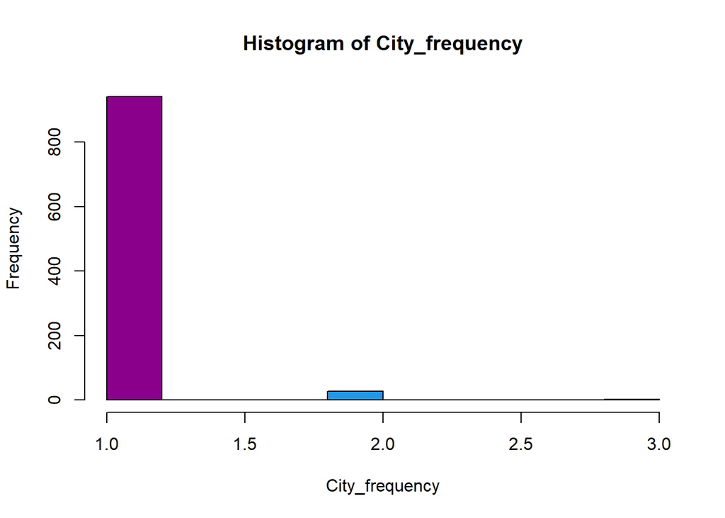

```r
City<-advertising$City
City_frequency<-table(advertising$City)

hist(City_frequency,col=c("darkmagenta",xlim=c(2,5),ylim=c(0,900)))
```

-We observe that most cities are mentioned only once(frequency=1) .

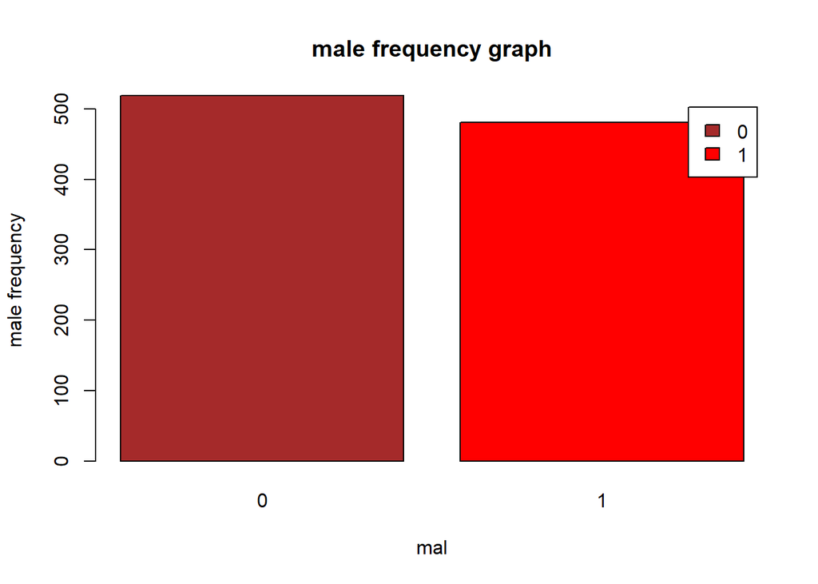

```r
count_male<-table(advertising$Male)
barplot(count_male,main="male frequency graph",xlab="mal",ylab="male frequency",legend=row.names(count_male),col=c("brown","red"))
```

# Bivariate Analysis

## Covariance

*Using the cov() function to determine the covariance*

```r
Age<-advertising$Age

Daily.Time.Spent.On.Site<-advertising$Daily.Time.Spent.on.Site

cov(Age,Daily.Time.Spent.On.Site)
```

```
## [1] -46.17415
```

_This indicates a negative relationship btwn age and daily time spent on site.Meaning the more the age,the lesser time spent on the sites of advertising.

*Covariance between age and daily internet usage*

```r
Age<-advertising$Age
Daily.Internet.Usage<-advertising$Daily.Internet.Usage
cov(Age,Daily.Internet.Usage)
```

```
## [1] -141.6348
```

-his also indicates negative relationship between age and daily internet ,Thus as the age increases,the daily internet usage reduces.

*Covariance between area income and daily internet usage*

```r
Area.Income<-advertising$Area.Income
Daily.Internet.Usage<-advertising$Daily.Internet.Usage
cov(Area.Income,Daily.Internet.Usage)
```

```
## [1] 198762.5
```

-This is a positive covariance indicating a positive relationship between the two variables. This means that the area with a high income also has a high internet usage and vice versa.

##Correlation Coefficient

*Correlation between age and daily internet usage*

```r
Age<-advertising$Age

Daily.Internet.Usage<-advertising$Daily.Internet.Usage

cor(Age,Daily.Internet.Usage)
```

```
## [1] -0.3672086
```

-This indicates a negative linear relationship between the variables.

*Correlation between age and daily time spent on site*

```r
Age<-advertising$Age

Daily.Time.Spent.on.Site<-advertising$Daily.Time.Spent.On.Site

cor(Age,Daily.Time.Spent.On.Site)
```

```
## [1] -0.3315133
```

-This also indicates a negative linear relationship between age and the daily time spent on sites.

*Correlation between age and area income**

```r
Age<-advertising$Age

Area.Income<-advertising$Area.Income

cor(Age,Area.Income)
```

```
## [1] -0.182605
```

-This indicates a negative linear relationship too.Perhaps because young people tend to be attracted to high income areas due to high disposable income.

*Correlation between area income and daily internet usage*

```r
Area.Income<-advertising$Area.Income

Daily.Internet.Usage<-advertising$Daily.Internet.Usage

cor(Area.Income,Daily.Internet.Usage)
```

```
## [1] 0.3374955
```

-This indicates a positive linear relationship between area income and daily internet usage.

# Multivariate Analysis

##Scatterplots -We shall create a scatter plot to visualize the trend between area income and daily internet usage

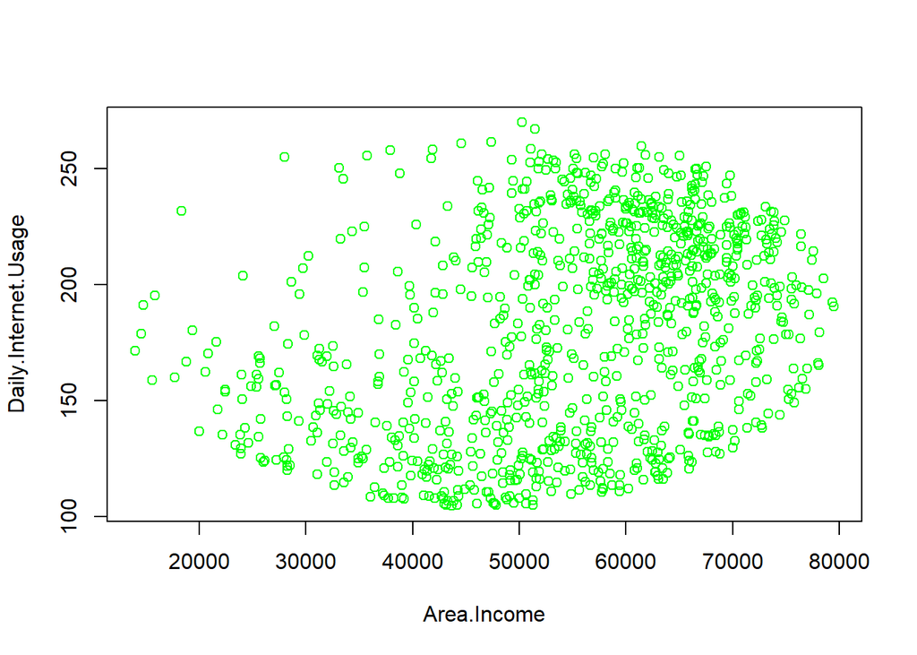

```r
Area.Income<-advertising$Area.Income

Daily.Internet.usage<-advertising$Daily.Internet.Income

plot(Area.Income,Daily.Internet.Usage,xlab="Area.Income",ylab="Daily.Internet.Usage",col=c("green"))
```

# Conclusions

-The most likely individuals to click on her AD are young people.

-There is no evidence that people from certain countries/city have higher chances of clicking her AD.(Anyone can click on her AD irrespective of the country/city)

-There’s a 50-50 chance of either clicking or not clicking her AD, based on the bargraph of those who clicked the AD.

#Recommedations

-The entreprenuer should target advertising on areas with high income.

-She should also target young people since they’re the ones who spents most time on sites.